# Taller 2 y 3 de fundamentos de programación.

11. Use la función gg_miss_fct para mostrar el comportamiento de los valores faltantes en esta base de datos, de acuerdo con las categorías de la variable region. ¿En cuál región parecen haber más valores faltantes para las variables expectativa_vida e ing_nac_ajustado? Repita el ejercicio pero ahora usando la variable income_level. ¿En cuál nivel de ingreso parecen haber más valores faltantes para las variables mencionadas.

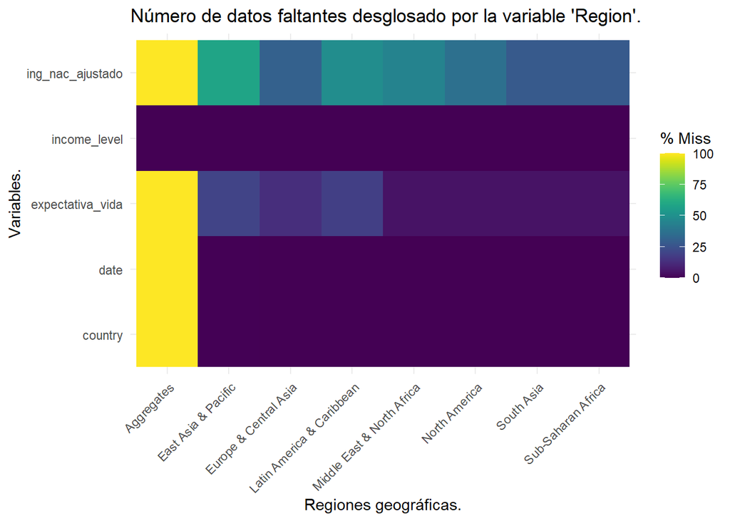

```r
gg_miss_fct(bm_principales, region) +
  labs(title = "Número de datos faltantes desglosado por la variable 'Region'.",
       x = "Regiones geográficas.",
       y = "Variables.")
```

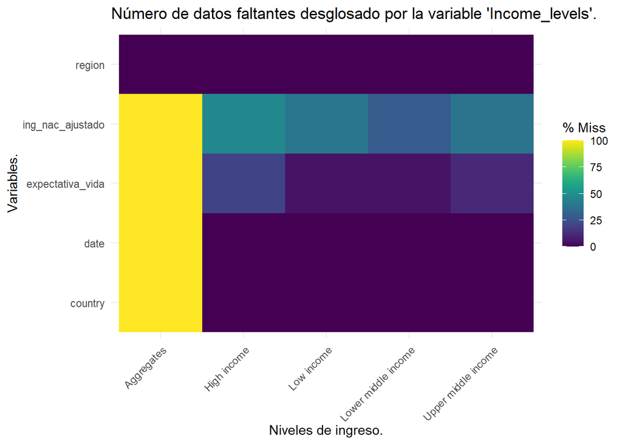

```r
gg_miss_fct(bm_principales, income_level) +
  labs(title = "Número de datos faltantes desglosado por la variable 'Income_levels'.",
       x = "Niveles de ingreso.",
       y = "Variables.")
```

**Comentario:**

En la región de Asia Oriental y el Pacífico parece tener más datos faltantes de la variable “ing_nac_ajustado”. Igualmente, las regiones de Asia oriental y el Pacífico y Latinoamérica y el Caribe parecen tener más datos faltantos que el resto de regiones en la variable “expectativa_vida”.

- El nivel de ingreso alto parece tener más datos faltantes con respecto al resto de niveles de ingreso, tanto para la variable “ing_nac_ajustado” como para la variable “expectativa_vida”.
12. Filtre el año 2015 y realice un diagrama de dispersión de las variables expectativa_vida (eje y) e ing_nac_ajustado (eje x) para ese año. El color de los puntos debe depender de la variable region. ¿Qué muestra la gráfica sobre la relación entre las variables para el 2015?

```r
bm_principales2015 <- bm_principales %>% filter(date == 2015)
head(bm_principales2015)
```

| country | date | region | income_level | ing_nac_ajustado | expectativa_vida |
| --- | --- | --- | --- | --- | --- |
| Aruba | 2015 | Latin America & Caribbean | High income | NA | 75.725 |
| Afghanistan | 2015 | South Asia | Low income | NA | 63.377 |
| Angola | 2015 | Sub-Saharan Africa | Lower middle income | 1643.821 | 59.398 |
| Albania | 2015 | Europe & Central Asia | Upper middle income | 3567.619 | 78.025 |
| Andorra | 2015 | Europe & Central Asia | High income | NA | NA |
| United Arab Emirates | 2015 | Middle East & North Africa | High income | 35474.124 | 77.285 |

```r
#View(bm_principales2015)
```

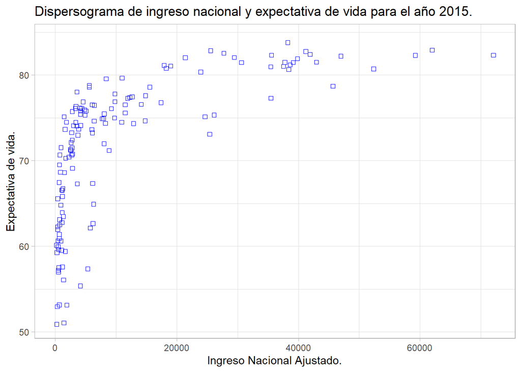

```r
ggplot(data = bm_principales2015,
       mapping = aes(x = ing_nac_ajustado,
                     y = expectativa_vida)) +
  geom_point(color = "Blue", shape = 0) +
  labs(title = "Dispersograma de ingreso nacional y expectativa de vida para el año 2015.",
       x = "Ingreso Nacional Ajustado.",
       y = "Expectativa de vida.") + theme_light()
```

**comentario:**

Se observa que los países con mayor ingreso nacional ajustado tienen la mayor expectativa de vida debido a que en su mayoría se trata de países desarrollados con una economica consolidada con una renta elevada y unos buenos indicadores de calidad de vida y bienestar. Por otro lado, aunque los países desarrollados presentan una expectativa de vida similar son muy diferentes en terminos de ingreso nacional ajustado.

Por otro lado, los países con menor ingreso nacional ajustado tienden a tener una menor expectativa de vida con respecto a los paíes desarrollados debido a que se trata de paises subdesarrollados o en vías de desarrollo con economias emergentes o periféricas y con indicadores de calidad de vida y bienestar menores. De manera análoga, aunque los países no desarrollados presentan un nivel de ingreso similar entre sí, son muy diferentes en terminos de expectativa de vida.

13. Filtre la información de Colombia y realice un diagrama de lineas que muestre la evolución de expectativa_vida en el periodo de análisis. ¿Qué muestra la gráfica sobre la evolución de la expectativa de vida desde el 2000?

```r
bm_colombia <- bm_principales %>% filter(country == "Colombia")
head(bm_colombia)
```

| country | date | region | income_level | ing_nac_ajustado | expectativa_vida |
| --- | --- | --- | --- | --- | --- |
| Colombia | 2020 | Latin America & Caribbean | Upper middle income | NA | NA |
| Colombia | 2019 | Latin America & Caribbean | Upper middle income | 6227.889 | 77.287 |
| Colombia | 2018 | Latin America & Caribbean | Upper middle income | 6151.357 | 77.109 |
| Colombia | 2017 | Latin America & Caribbean | Upper middle income | 6128.239 | 76.925 |
| Colombia | 2016 | Latin America & Caribbean | Upper middle income | 6150.414 | 76.732 |
| Colombia | 2015 | Latin America & Caribbean | Upper middle income | 6085.511 | 76.531 |

```r
#View(bm_colombia)
```

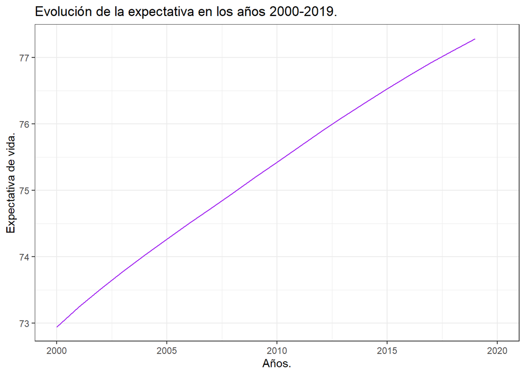

```r
ggplot(data = bm_colombia, mapping = aes(x = date, y = expectativa_vida)) +
  geom_line(color = "purple") +
  labs(title = "Evolución de la expectativa en los años 2000-2019.",
       x = "Años.",
       y = "Expectativa de vida.") +
  theme_bw()
```

**Comentario:**

El diagrama de expectativa de vida durante los años 2000 a 2019, muestra que la expectativa de vida crece de manera sostenida y uniforme en este periodo de tiempo en Colombia.